# Chapter52.Rmd

Maria Karolina Wickholm

5 joulukuuta 2017

## Chapter5

install.packages(“FactoMineR”) Access GGally

```r
library(GGally)
library(corrplot)
library(tidyr)
library(ggplot2)
library(FactoMineR)
library (stringr)
```

Load the ‘human’ data into R. Explore the structure and the dimensions of the data and describe the dataset briefly, assuming the reader has no ’ previous knowledge of it (this is now close to the reality, since you have named the variables yourself). (0-1 point) the file path of the data

load the data

```r
human<- read.table("http://s3.amazonaws.com/assets.datacamp.com/production/course_2218/datasets/human1.txt", sep=",", header = T)
dim(human)
```

```
## [1] 195  19
```

the dimension of the data The Human data has 195 observations and 19 variables

```r
str(human)
```

```
## 'data.frame':    195 obs. of  19 variables:
##  $ HDI.Rank      : int  1 2 3 4 5 6 6 8 9 9 ...
##  $ Country       : Factor w/ 195 levels "Afghanistan",..: 129 10 169 48 124 67 84 186 34 125 ...
##  $ HDI           : num  0.944 0.935 0.93 0.923 0.922 0.916 0.916 0.915 0.913 0.913 ...
##  $ Life.Exp      : num  81.6 82.4 83 80.2 81.6 80.9 80.9 79.1 82 81.8 ...
##  $ Edu.Exp       : num  17.5 20.2 15.8 18.7 17.9 16.5 18.6 16.5 15.9 19.2 ...
##  $ Edu.Mean      : num  12.6 13 12.8 12.7 11.9 13.1 12.2 12.9 13 12.5 ...
##  $ GNI           : Factor w/ 194 levels "1,096","1,123",..: 166 135 156 139 140 137 127 154 134 117 ...
##  $ GNI.Minus.Rank: int  5 17 6 11 9 11 16 3 11 23 ...
##  $ GII.Rank      : int  1 2 3 4 5 6 6 8 9 9 ...
##  $ GII           : num  0.067 0.11 0.028 0.048 0.062 0.041 0.113 0.28 0.129 0.157 ...
##  $ Mat.Mor       : int  4 6 6 5 6 7 9 28 11 8 ...
##  $ Ado.Birth     : num  7.8 12.1 1.9 5.1 6.2 3.8 8.2 31 14.5 25.3 ...
##  $ Parli.F       : num  39.6 30.5 28.5 38 36.9 36.9 19.9 19.4 28.2 31.4 ...
##  $ Edu2.F        : num  97.4 94.3 95 95.5 87.7 96.3 80.5 95.1 100 95 ...
##  $ Edu2.M        : num  96.7 94.6 96.6 96.6 90.5 97 78.6 94.8 100 95.3 ...
##  $ Labo.F        : num  61.2 58.8 61.8 58.7 58.5 53.6 53.1 56.3 61.6 62 ...
##  $ Labo.M        : num  68.7 71.8 74.9 66.4 70.6 66.4 68.1 68.9 71 73.8 ...
##  $ Edu2.FM       : num  1.007 0.997 0.983 0.989 0.969 ...
##  $ Labo.FM       : num  0.891 0.819 0.825 0.884 0.829 ...
```

The Human data has 195 observations and 19 variables Description of the data set Origin of the data: http://hdr.undp.org/en/content/human-development-index-hdi

Below are the column names and their full meanings “Country” = Country name “GNI” = Gross National Income per capita “Life.Exp” = Life expectancy at birth “Edu.Exp” = Expected years of schooling “Mat.Mor” = Maternal mortality ratio “Ado.Birth” = Adolescent birth rate

Mutate the data: transform the Gross National Income (GNI) variable to numeric (Using string manipulation. Note that the mutation of ‘human’ was not done on DataCamp). (1 point)

```r
human$GNI <- str_replace(human$GNI, pattern=",", replace ="") %>% as.numeric
```

```r
str(human$GNI)
```

```
##  num [1:195] 64992 42261 56431 44025 45435 ...
```

Exclude unneeded variables: keep only the columns matching the following variable names (described in the meta file above):  
“Country”, “Edu2.FM”, “Labo.FM”, “Edu.Exp”, “Life.Exp”, “GNI”, “Mat.Mor”, “Ado.Birth”, “Parli.F” (1 point)

```r
keep <- c("Country", "Edu2.FM", "Labo.FM", "Life.Exp", "Edu.Exp", "GNI", "Mat.Mor", "Ado.Birth", "Parli.F")
```

Remove all rows with missing values (1 point).

```r
library("dplyr")
human <- select(human, one_of(keep))
data.frame(human[-1], comp = complete.cases(human))
```

[output not shown]

[output cut: 377 more lines]

```r
human_ <- filter(human, complete.cases(human))
```

Remove the observations which relate to regions instead of countries. (1 point)

```r
last <- nrow(human_) - 7
human_ <- human_[1:last,]
```

Define the row names of the data by the country names and remove the country name column from the data. The data should now have 155 observations and 8 variables. Save the human data in your data folder including the row names. You can overwrite your old ‘human’ data. (1 point)

```r
rownames(human_) <- human_$Country
human_ <- select(human_, -Country)
```

The human_ data has now 155 observations and 8 variables Data wrangled YEAH!!

```r
str(human_)
```

```
## 'data.frame':    155 obs. of  8 variables:
##  $ Edu2.FM  : num  1.007 0.997 0.983 0.989 0.969 ...
##  $ Labo.FM  : num  0.891 0.819 0.825 0.884 0.829 ...
##  $ Life.Exp : num  81.6 82.4 83 80.2 81.6 80.9 80.9 79.1 82 81.8 ...
##  $ Edu.Exp  : num  17.5 20.2 15.8 18.7 17.9 16.5 18.6 16.5 15.9 19.2 ...
##  $ GNI      : num  64992 42261 56431 44025 45435 ...
##  $ Mat.Mor  : int  4 6 6 5 6 7 9 28 11 8 ...
##  $ Ado.Birth: num  7.8 12.1 1.9 5.1 6.2 3.8 8.2 31 14.5 25.3 ...
##  $ Parli.F  : num  39.6 30.5 28.5 38 36.9 36.9 19.9 19.4 28.2 31.4 ...
```

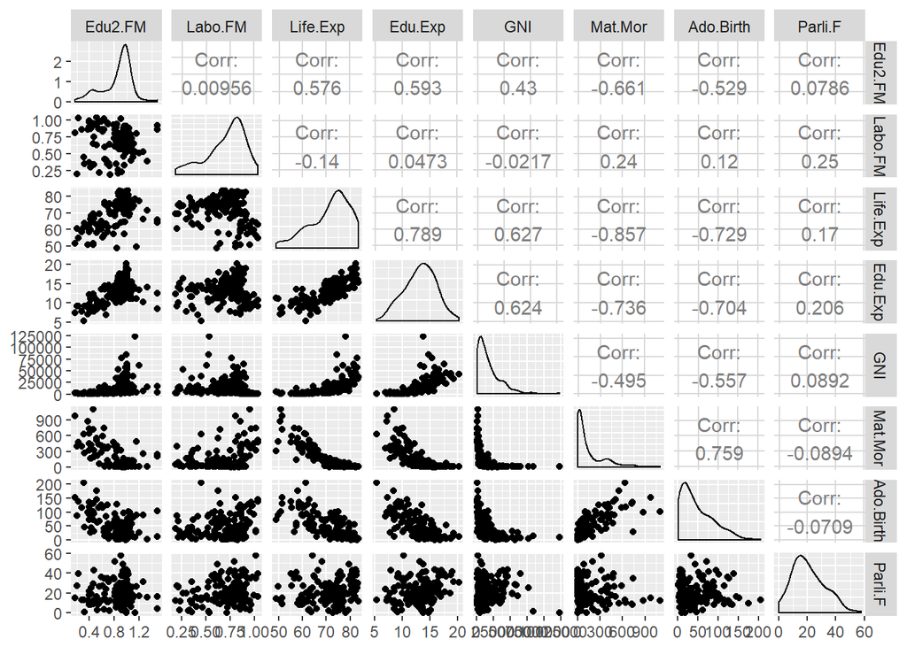

```r
library(GGally)
ggpairs(human_)
```

Show a graphical overview of the data and show summaries of the variables in the data. Describe and interpret the outputs, commenting on the distributions of the variables and the relationships between them. (0-2 points)

From the plot drawn with ggpairs, we can see that some variables seem to correlate more positive or negative, compared to others. For example, life expectancy at birth and expected years of education have a pretty high correlation (0.789). Also the maternal mortality ratio has a high correlation with life expectancy at birth (-0.857). Basicly, the further away from 0, both positive and negative, gives a hint about which variables seem to correlate with others.

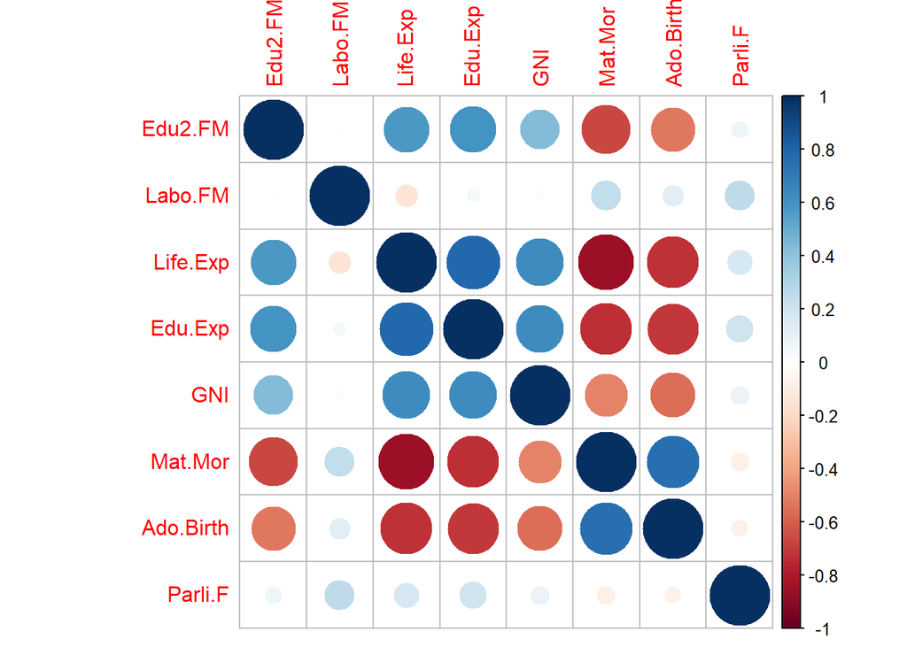

```r
cor(human_)%>%corrplot()
```

```r
summary(human_)
```

```
##     Edu2.FM          Labo.FM          Life.Exp        Edu.Exp
##  Min.   :0.1717   Min.   :0.1857   Min.   :49.00   Min.   : 5.40
##  1st Qu.:0.7264   1st Qu.:0.5984   1st Qu.:66.30   1st Qu.:11.25
##  Median :0.9375   Median :0.7535   Median :74.20   Median :13.50
##  Mean   :0.8529   Mean   :0.7074   Mean   :71.65   Mean   :13.18
##  3rd Qu.:0.9968   3rd Qu.:0.8535   3rd Qu.:77.25   3rd Qu.:15.20
##  Max.   :1.4967   Max.   :1.0380   Max.   :83.50   Max.   :20.20
##       GNI            Mat.Mor         Ado.Birth         Parli.F
##  Min.   :   581   Min.   :   1.0   Min.   :  0.60   Min.   : 0.00
##  1st Qu.:  4198   1st Qu.:  11.5   1st Qu.: 12.65   1st Qu.:12.40
##  Median : 12040   Median :  49.0   Median : 33.60   Median :19.30
##  Mean   : 17628   Mean   : 149.1   Mean   : 47.16   Mean   :20.91
##  3rd Qu.: 24512   3rd Qu.: 190.0   3rd Qu.: 71.95   3rd Qu.:27.95
##  Max.   :123124   Max.   :1100.0   Max.   :204.80   Max.   :57.50
```

```r
pca_unstand_human<- prcomp(human_)
s_hum<-summary(pca_unstand_human)
s_hum
```

```
## Importance of components:
##                              PC1      PC2   PC3   PC4   PC5   PC6    PC7
## Standard deviation     1.854e+04 185.5219 25.19 11.45 3.766 1.566 0.1912
## Proportion of Variance 9.999e-01   0.0001  0.00  0.00 0.000 0.000 0.0000
## Cumulative Proportion  9.999e-01   1.0000  1.00  1.00 1.000 1.000 1.0000
##                           PC8
## Standard deviation     0.1591
## Proportion of Variance 0.0000
## Cumulative Proportion  1.0000
```

Perform principal component analysis (PCA) on the not standardized human data. Show the variability captured by the principal components. Draw a biplot displaying the observations by the first two principal components (PC1 coordinate in x-axis, PC2 coordinate in y-axis), along with arrows representing the original variables. (0-2 points)

```r
pca_pro<- round(100*s_hum$importance[2,], digits = 3)
pca_pro
```

```
##   PC1   PC2   PC3   PC4   PC5   PC6   PC7   PC8
## 99.99  0.01  0.00  0.00  0.00  0.00  0.00  0.00
```

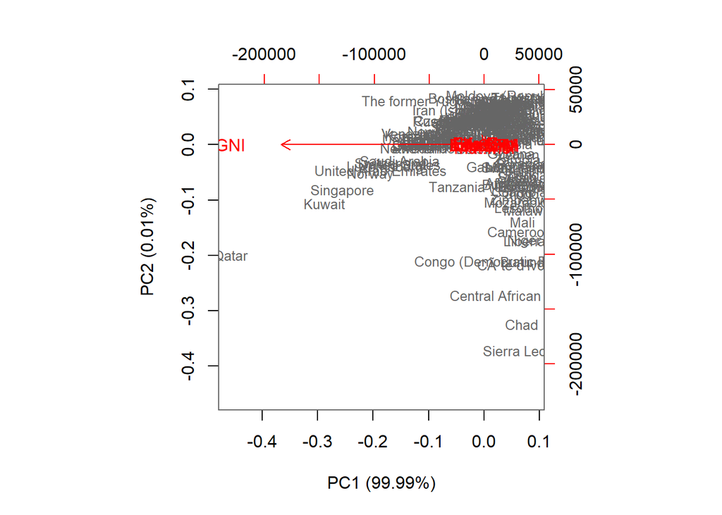

```r
pc_label<-paste0(names(pca_pro), " (", pca_pro, "%)")
biplot(pca_unstand_human, cex = c(0.8, 1), col = c("grey40", "red"), xlab = pc_label[1], ylab = pc_label[2])
```

Perform principal component analysis (PCA) on the not standardized human data. Show the variability captured by the principal components. Draw a biplot displaying the observations by the first two principal components (PC1 coordinate in x-axis, PC2 coordinate in y-axis), along with arrows representing the original variables. (0-2 points)

```r
human_scaled<- scale(human_)
summary(human_scaled)
```

```
##     Edu2.FM           Labo.FM           Life.Exp          Edu.Exp
##  Min.   :-2.8189   Min.   :-2.6247   Min.   :-2.7188   Min.   :-2.7378
##  1st Qu.:-0.5233   1st Qu.:-0.5484   1st Qu.:-0.6425   1st Qu.:-0.6782
##  Median : 0.3503   Median : 0.2316   Median : 0.3056   Median : 0.1140
##  Mean   : 0.0000   Mean   : 0.0000   Mean   : 0.0000   Mean   : 0.0000
##  3rd Qu.: 0.5958   3rd Qu.: 0.7350   3rd Qu.: 0.6717   3rd Qu.: 0.7126
##  Max.   : 2.6646   Max.   : 1.6632   Max.   : 1.4218   Max.   : 2.4730
##       GNI             Mat.Mor          Ado.Birth          Parli.F
##  Min.   :-0.9193   Min.   :-0.6992   Min.   :-1.1325   Min.   :-1.8203
##  1st Qu.:-0.7243   1st Qu.:-0.6496   1st Qu.:-0.8394   1st Qu.:-0.7409
##  Median :-0.3013   Median :-0.4726   Median :-0.3298   Median :-0.1403
##  Mean   : 0.0000   Mean   : 0.0000   Mean   : 0.0000   Mean   : 0.0000
##  3rd Qu.: 0.3712   3rd Qu.: 0.1932   3rd Qu.: 0.6030   3rd Qu.: 0.6127
##  Max.   : 5.6890   Max.   : 4.4899   Max.   : 3.8344   Max.   : 3.1850
```

Standardize the variables in the human data and repeat the above analysis. Interpret the results of both analysis (with and without standardizing). Are the results different? Why or why not? Include captions in you plots where you describe the results by using not just your variable names, but the actual phenomenons they relate to. (0-4 points)

```r
pca_human_scaled<- prcomp(human_scaled)
s_hum2<-summary(pca_human_scaled)
s_hum2
```

```
## Importance of components:
##                           PC1    PC2     PC3     PC4     PC5     PC6
## Standard deviation     2.0708 1.1397 0.87505 0.77886 0.66196 0.53631
## Proportion of Variance 0.5361 0.1624 0.09571 0.07583 0.05477 0.03595
## Cumulative Proportion  0.5361 0.6984 0.79413 0.86996 0.92473 0.96069
##                            PC7     PC8
## Standard deviation     0.45900 0.32224
## Proportion of Variance 0.02634 0.01298
## Cumulative Proportion  0.98702 1.00000
```

```r
pca_pro2<- round(100*s_hum2$importance[2,], digits = 3)
pca_pro2
```

```
##    PC1    PC2    PC3    PC4    PC5    PC6    PC7    PC8
## 53.605 16.237  9.571  7.583  5.477  3.595  2.634  1.298
```

```r
pc_label2<-paste0(names(pca_pro2), " (", pca_pro2, "%)")
par(mfrow=c(2,1))
```

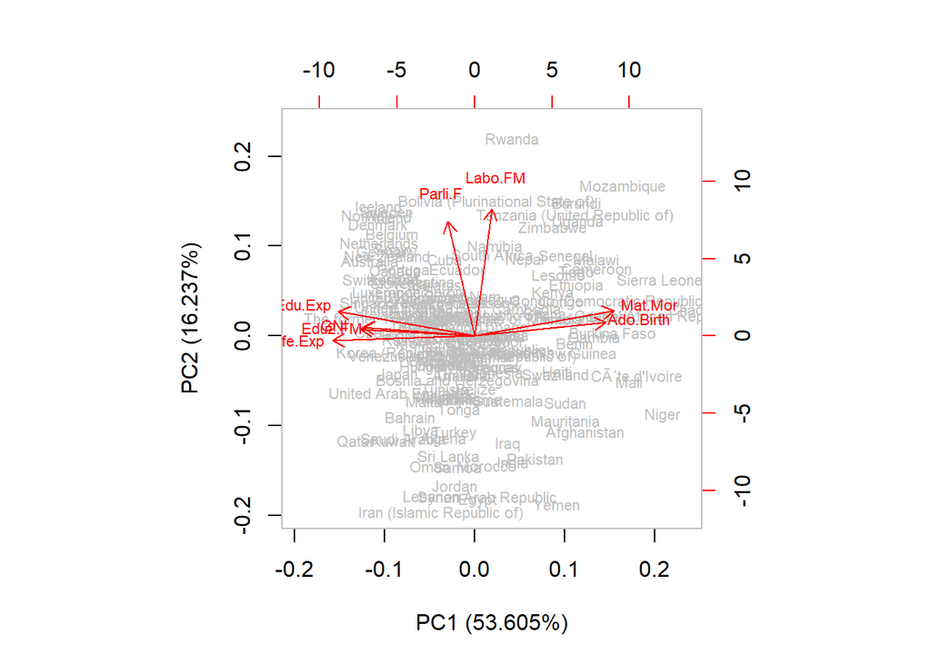

```r
biplot(pca_human_scaled, cex = c(0.7, 0.7), col = c("grey", "red"), xlab = pc_label2[1], ylab = pc_label2[2])
```

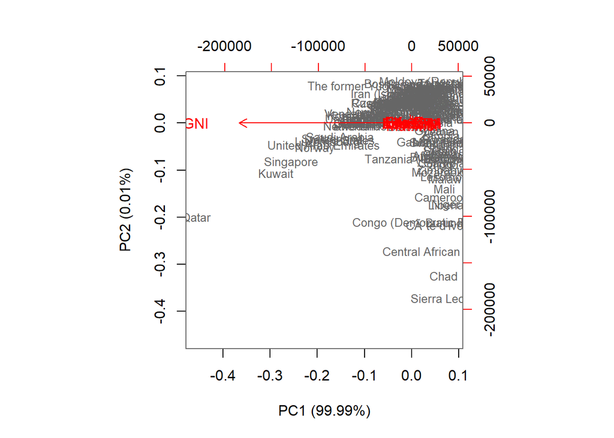

```r
biplot(pca_unstand_human, cex = c(0.8, 1), col = c("grey40", "red"), xlab = pc_label[1], ylab = pc_label[2])
```

Give your personal interpretations of the first two principal component dimensions based on the biplot drawn after PCA on the standardized human data. (0-2 points) From the biplots we can see that the biplot drawn with unscaled variables differ a lot from the biplot drawn with scaled variables. The unscaled one is messy and the only variable that can be seen is the GNI. This is due to the differences in values in the unscaled variables.From the scaled biplot can be seen that the proportion of females in the labour force and the Percetange of female representatives in parliament are almost at a 90 degree angle and therefor less related to Maternal mortality ratio, than for example Adolescent birth rate, Expected years of schooling and Life expectancy at birth.

```r
library("FactoMineR")
data(tea)
str(tea)
```

```
## 'data.frame':    300 obs. of  36 variables:
##  $ breakfast       : Factor w/ 2 levels "breakfast","Not.breakfast": 1 1 2 2 1 2 1 2 1 1 ...
##  $ tea.time        : Factor w/ 2 levels "Not.tea time",..: 1 1 2 1 1 1 2 2 2 1 ...
##  $ evening         : Factor w/ 2 levels "evening","Not.evening": 2 2 1 2 1 2 2 1 2 1 ...
##  $ lunch           : Factor w/ 2 levels "lunch","Not.lunch": 2 2 2 2 2 2 2 2 2 2 ...
##  $ dinner          : Factor w/ 2 levels "dinner","Not.dinner": 2 2 1 1 2 1 2 2 2 2 ...
##  $ always          : Factor w/ 2 levels "always","Not.always": 2 2 2 2 1 2 2 2 2 2 ...
##  $ home            : Factor w/ 2 levels "home","Not.home": 1 1 1 1 1 1 1 1 1 1 ...
##  $ work            : Factor w/ 2 levels "Not.work","work": 1 1 2 1 1 1 1 1 1 1 ...
##  $ tearoom         : Factor w/ 2 levels "Not.tearoom",..: 1 1 1 1 1 1 1 1 1 2 ...
##  $ friends         : Factor w/ 2 levels "friends","Not.friends": 2 2 1 2 2 2 1 2 2 2 ...
##  $ resto           : Factor w/ 2 levels "Not.resto","resto": 1 1 2 1 1 1 1 1 1 1 ...
##  $ pub             : Factor w/ 2 levels "Not.pub","pub": 1 1 1 1 1 1 1 1 1 1 ...
##  $ Tea             : Factor w/ 3 levels "black","Earl Grey",..: 1 1 2 2 2 2 2 1 2 1 ...
##  $ How             : Factor w/ 4 levels "alone","lemon",..: 1 3 1 1 1 1 1 3 3 1 ...
```

[output cut: 22 more lines]

```r
dim(tea)
```

```
## [1] 300  36
```

Load the tea dataset from the package Factominer. Explore the data briefly: look at the structure and the dimensions of the data and visualize it. Then do Multiple Correspondence Analysis on the tea data (or to a certain columns of the data, it’s up to you). Interpret the results of the MCA and draw at least the variable biplot of the analysis. You can also explore other plotting options for MCA. Comment on the output of the plots. (0-4 points)

```r
colnames(tea)
```

```
##  [1] "breakfast"        "tea.time"         "evening"
##  [4] "lunch"            "dinner"           "always"
##  [7] "home"             "work"             "tearoom"
## [10] "friends"          "resto"            "pub"
## [13] "Tea"              "How"              "sugar"
## [16] "how"              "where"            "price"
## [19] "age"              "sex"              "SPC"
## [22] "Sport"            "age_Q"            "frequency"
## [25] "escape.exoticism" "spirituality"     "healthy"
## [28] "diuretic"         "friendliness"     "iron.absorption"
## [31] "feminine"         "sophisticated"    "slimming"
## [34] "exciting"         "relaxing"         "effect.on.health"
```

```r
keep_columns <- c("Tea", "How", "how", "sugar", "where","lunch", "dinner", "always")
```

```r
tea_time <- tea[, keep_columns]
```

```r
summary(tea_time)
```

```
##         Tea         How                      how           sugar
##  black    : 74   alone:195   tea bag           :170   No.sugar:155
##  Earl Grey:193   lemon: 33   tea bag+unpackaged: 94   sugar   :145
##  green    : 33   milk : 63   unpackaged        : 36
##                  other:  9
##                   where           lunch            dinner
##  chain store         :192   lunch    : 44   dinner    : 21
##  chain store+tea shop: 78   Not.lunch:256   Not.dinner:279
##  tea shop            : 30
##
##         always
##  always    :103
##  Not.always:197
##
##
```

```r
str(tea_time)
```

```
## 'data.frame':    300 obs. of  8 variables:
##  $ Tea   : Factor w/ 3 levels "black","Earl Grey",..: 1 1 2 2 2 2 2 1 2 1 ...
##  $ How   : Factor w/ 4 levels "alone","lemon",..: 1 3 1 1 1 1 1 3 3 1 ...
##  $ how   : Factor w/ 3 levels "tea bag","tea bag+unpackaged",..: 1 1 1 1 1 1 1 1 2 2 ...
##  $ sugar : Factor w/ 2 levels "No.sugar","sugar": 2 1 1 2 1 1 1 1 1 1 ...
##  $ where : Factor w/ 3 levels "chain store",..: 1 1 1 1 1 1 1 1 2 2 ...
##  $ lunch : Factor w/ 2 levels "lunch","Not.lunch": 2 2 2 2 2 2 2 2 2 2 ...
##  $ dinner: Factor w/ 2 levels "dinner","Not.dinner": 2 2 1 1 2 1 2 2 2 2 ...
##  $ always: Factor w/ 2 levels "always","Not.always": 2 2 2 2 1 2 2 2 2 2 ...
```

```r
library("tidyverse")
```

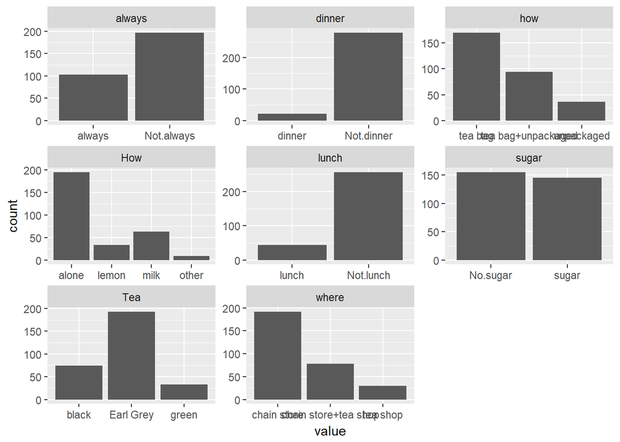

```r
gather(tea_time) %>% ggplot(aes(value)) + facet_wrap("key", scales = "free") + geom_bar()
```

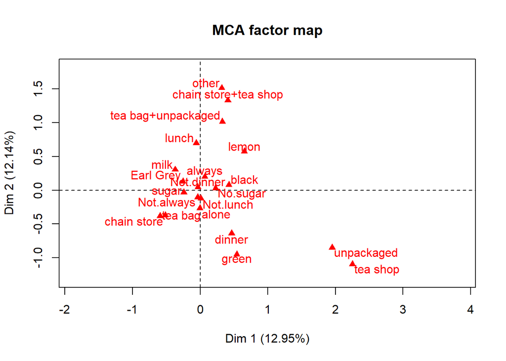

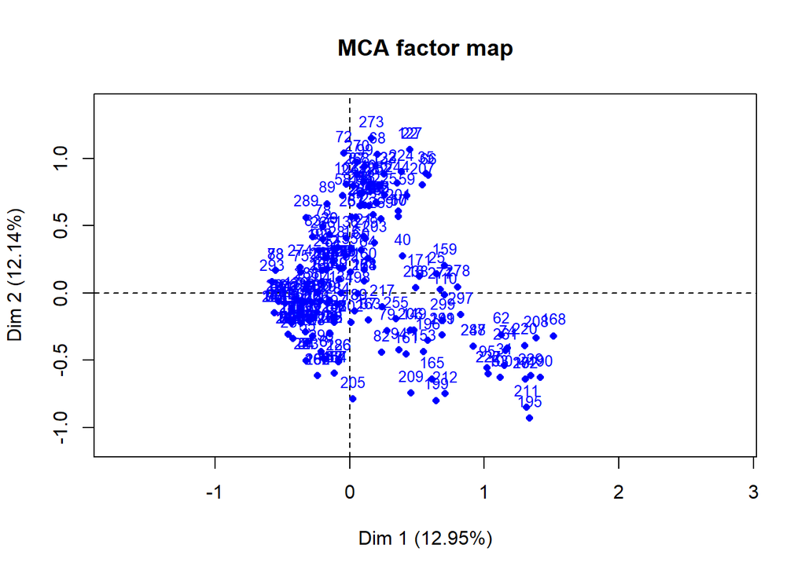

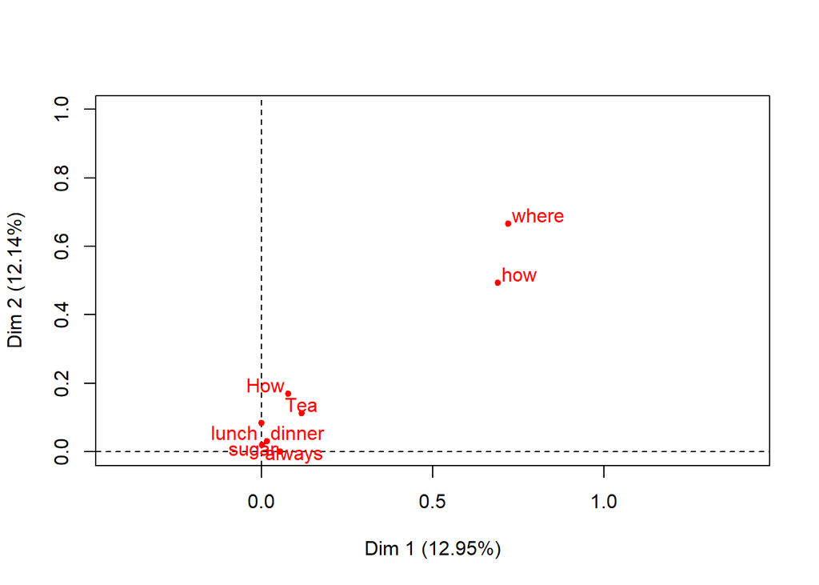

```r
mca <- MCA(tea_time, graph = T)
```

```r
mca$eig
```

```
##        eigenvalue percentage of variance cumulative percentage of variance
## dim 1  0.21048449              12.952892                          12.95289
## dim 2  0.19732595              12.143135                          25.09603
## dim 3  0.16859765              10.375240                          35.47127
## dim 4  0.15443866               9.503918                          44.97518
## dim 5  0.14173776               8.722324                          53.69751
## dim 6  0.13156516               8.096318                          61.79383
## dim 7  0.12258668               7.543795                          69.33762
## dim 8  0.10930176               6.726262                          76.06388
## dim 9  0.10465782               6.440481                          82.50437
## dim 10 0.09671587               5.951746                          88.45611
## dim 11 0.08479186               5.217960                          93.67407
## dim 12 0.05844278               3.596478                          97.27055
## dim 13 0.04435357               2.729450                         100.00000
```

```r
summary(mca)
```

```
##
## Call:
## MCA(X = tea_time, graph = T)
##
##
## Eigenvalues
##                        Dim.1   Dim.2   Dim.3   Dim.4   Dim.5   Dim.6
## Variance               0.210   0.197   0.169   0.154   0.142   0.132
## % of var.             12.953  12.143  10.375   9.504   8.722   8.096
## Cumulative % of var.  12.953  25.096  35.471  44.975  53.698  61.794
##                        Dim.7   Dim.8   Dim.9  Dim.10  Dim.11  Dim.12
## Variance               0.123   0.109   0.105   0.097   0.085   0.058
## % of var.              7.544   6.726   6.440   5.952   5.218   3.596
## Cumulative % of var.  69.338  76.064  82.504  88.456  93.674  97.271
##                       Dim.13
## Variance               0.044
## % of var.              2.729
## Cumulative % of var. 100.000
##
## Individuals (the 10 first)
##                       Dim.1    ctr   cos2    Dim.2    ctr   cos2    Dim.3
## 1                  | -0.272  0.117  0.087 | -0.322  0.175  0.123 |  0.323
## 2                  | -0.243  0.094  0.048 | -0.144  0.035  0.017 |  0.588
## 3                  | -0.192  0.059  0.017 | -0.483  0.394  0.108 |  0.400
## 4                  | -0.321  0.163  0.047 | -0.500  0.423  0.115 |  0.089
## 5                  | -0.300  0.142  0.131 | -0.205  0.071  0.061 | -0.046
## 6                  | -0.192  0.059  0.017 | -0.483  0.394  0.108 |  0.400
## 7                  | -0.328  0.171  0.209 | -0.290  0.142  0.163 |  0.189
## 8                  | -0.243  0.094  0.048 | -0.144  0.035  0.017 |  0.588
## 9                  |  0.076  0.009  0.004 |  0.742  0.930  0.398 |  0.151
## 10                 |  0.361  0.206  0.101 |  0.567  0.543  0.249 |  0.643
##                       ctr   cos2
## 1                   0.207  0.124 |
## 2                   0.683  0.281 |
## 3                   0.317  0.074 |
## 4                   0.016  0.004 |
## 5                   0.004  0.003 |
## 6                   0.317  0.074 |
## 7                   0.070  0.069 |
## 8                   0.683  0.281 |
```

[output cut: 22 more lines]

```
## other                0.071   4.604 |   2.822  17.710   0.246   8.581 |
## tea bag              0.191  -7.553 |   0.049   0.102   0.003   0.975 |
## tea bag+unpackaged   0.471  11.871 |   0.062   0.089   0.002   0.725 |
## unpackaged           0.098  -5.426 |  -0.395   1.387   0.021  -2.522 |
##
## Categorical variables (eta2)
##                      Dim.1 Dim.2 Dim.3
## Tea                | 0.118 0.112 0.383 |
## How                | 0.079 0.170 0.361 |
## how                | 0.691 0.493 0.021 |
## sugar              | 0.055 0.001 0.261 |
## where              | 0.722 0.667 0.054 |
## lunch              | 0.001 0.084 0.103 |
## dinner             | 0.016 0.031 0.031 |
## always             | 0.002 0.021 0.134 |
```

```r
dimdesc(mca)
```

```
## $`Dim 1`
## $`Dim 1`$quali
##                R2      p.value
## where  0.72150089 3.600284e-83
## how    0.69065552 2.141372e-76
## Tea    0.11815285 7.778702e-09
## How    0.07880121 2.125113e-05
## sugar  0.05549847 3.764045e-05
## dinner 0.01622301 2.739186e-02
##
## $`Dim 1`$category
##                         Estimate      p.value
## tea shop              0.70469065 2.025727e-55
## unpackaged            0.63758220 2.649774e-49
## black                 0.08592169 2.187750e-05
## No.sugar              0.10814140 3.764045e-05
## lemon                 0.23130326 6.064752e-05
## green                 0.13942755 9.454397e-04
## dinner                0.11451313 2.739186e-02
## Not.dinner           -0.11451313 2.739186e-02
## milk                 -0.23834687 8.633884e-04
## tea bag+unpackaged   -0.10730724 1.111331e-04
## sugar                -0.10814140 3.764045e-05
## chain store+tea shop -0.13956077 2.119180e-05
## Earl Grey            -0.22534924 1.146406e-09
## tea bag              -0.53027496 5.326211e-42
## chain store          -0.56512988 7.733039e-44
##
##
## $`Dim 2`
## $`Dim 2`$quali
##                R2      p.value
## where  0.66686927 1.283167e-71
## how    0.49298923 1.566940e-44
## How    0.17015423 5.924610e-12
## Tea    0.11245323 2.024886e-08
## lunch  0.08385183 3.319034e-07
## dinner 0.03055761 2.377263e-03
## always 0.02079111 1.241520e-02
##
```

[output cut: 35 more lines]

```
##              Estimate      p.value
## black       0.3314010 1.334673e-30
## No.sugar    0.2096987 2.640692e-21
## other       0.9760355 4.683939e-20
## Not.always  0.1585503 5.582660e-11
## Not.lunch   0.1864906 1.236895e-08
## dinner      0.1426990 2.046947e-03
## unpackaged -0.1233410 1.144699e-02
## Not.dinner -0.1426990 2.046947e-03
## tea shop   -0.2134915 4.614786e-05
## lunch      -0.1864906 1.236895e-08
## lemon      -0.6062225 9.296952e-11
## always     -0.1585503 5.582660e-11
## sugar      -0.2096987 2.640692e-21
## Earl Grey  -0.2694768 4.163234e-26
```

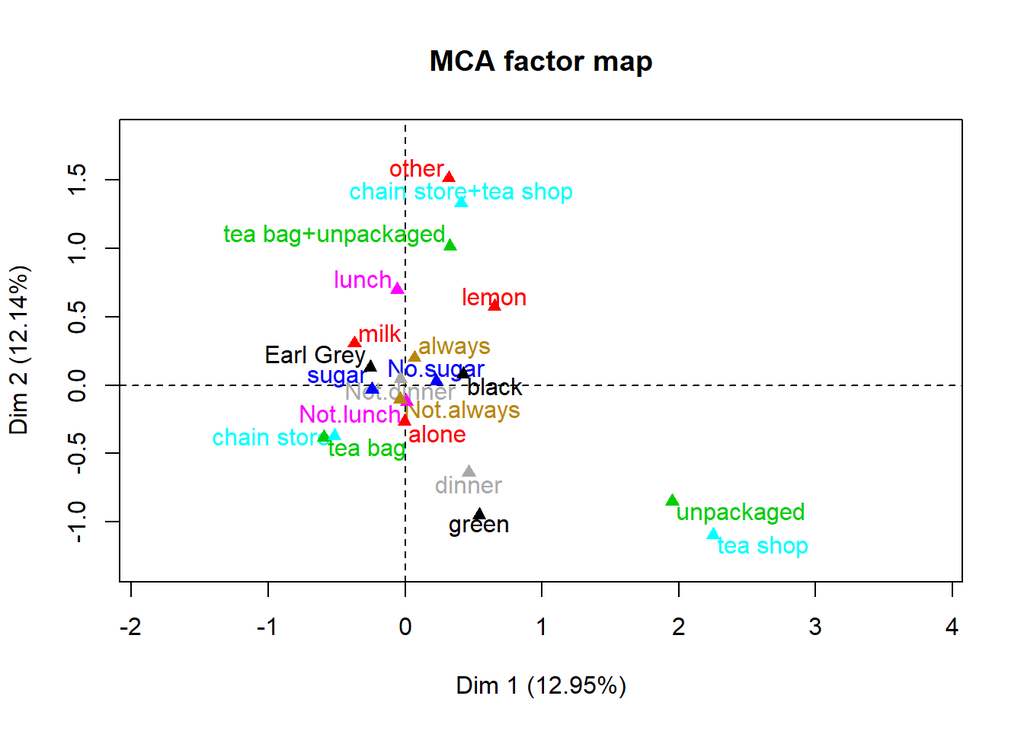

```r
plot(mca, invisible=c("ind"), habillage="quali")
```

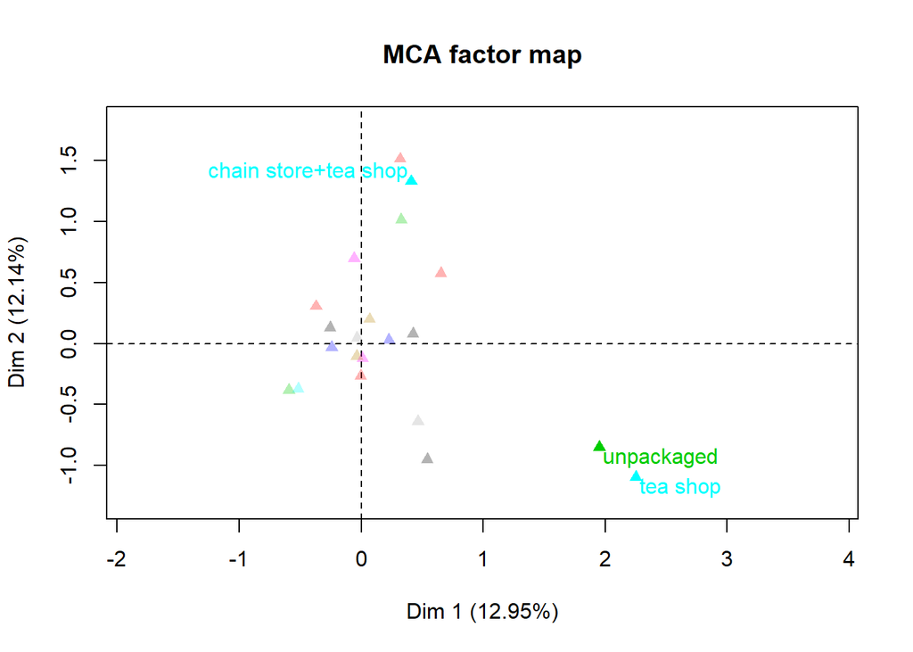

```r
plot(mca, invisible=c("ind"), habillage="quali", selectMod = "contrib 3")
```

```r
mca
```

```
## **Results of the Multiple Correspondence Analysis (MCA)**
## The analysis was performed on 300 individuals, described by 8 variables
## *The results are available in the following objects:
##
##    name              description
## 1  "$eig"            "eigenvalues"
## 2  "$var"            "results for the variables"
## 3  "$var$coord"      "coord. of the categories"
## 4  "$var$cos2"       "cos2 for the categories"
## 5  "$var$contrib"    "contributions of the categories"
## 6  "$var$v.test"     "v-test for the categories"
## 7  "$ind"            "results for the individuals"
## 8  "$ind$coord"      "coord. for the individuals"
## 9  "$ind$cos2"       "cos2 for the individuals"
## 10 "$ind$contrib"    "contributions of the individuals"
## 11 "$call"           "intermediate results"
## 12 "$call$marge.col" "weights of columns"
## 13 "$call$marge.li"  "weights of rows"
```

```r
categ = apply(tea_time, 2, function(x) nlevels(as.factor(x)))
categ
```

```
##    Tea    How    how  sugar  where  lunch dinner always
##      3      4      3      2      3      2      2      2
```

```r
rep("c", 3)
```

```
## [1] "c" "c" "c"
```

```r
mca_vars_df = data.frame(mca$var$coord, Variable = rep(names(categ), categ))
mca_vars_df
```

```
##                             Dim.1       Dim.2       Dim.3        Dim.4
## black                 0.423651485  0.08107960  1.04681861 -0.585421744
## Earl Grey            -0.254815184  0.13167636 -0.41657241  0.206151622
## green                 0.540276385 -0.95192208  0.08890598  0.107089275
## alone                -0.005145665 -0.26532782  0.07089725 -0.008821771
## lemon                 0.652506444  0.57311193 -1.03170232  0.716796890
## milk                 -0.371173973  0.30477825 -0.08213745 -0.590809805
## other                 0.317183601  1.51391127  2.82176366  1.698551747
## tea bag              -0.594335503 -0.38199371  0.04930828  0.023211198
## tea bag+unpackaged    0.327592844  1.01630733  0.06206211  0.172077242
## unpackaged            1.951203005 -0.84983218 -0.39489575 -0.558921233
## No.sugar              0.227855056  0.02967102  0.49368134 -0.371161035
## sugar                -0.243569198 -0.03171729 -0.52772833  0.396758347
## chain store          -0.517954077 -0.36948069  0.07302572 -0.106496997
## chain store+tea shop  0.409644442  1.33003920  0.08904367  0.193338346
## tea shop              2.249830542 -1.09342548 -0.69887815  0.178901081
## lunch                -0.059801438  0.69847346 -0.77513934 -0.702690710
## Not.lunch             0.010278372 -0.12005013  0.13322707  0.120774966
## dinner                0.464256677 -0.63716529  0.64640998  2.706238251
## Not.dinner           -0.034944051  0.04795868 -0.04865451 -0.203695352
## always                0.068164509  0.19941295 -0.50712645 -0.325285068
## Not.always           -0.035639312 -0.10426159  0.26514733  0.170072904
##                            Dim.5 Variable
## black                 0.71760141      Tea
## Earl Grey            -0.02900587      Tea
## green                -1.43952642      Tea
## alone                -0.43351279      How
## lemon                 0.98168642      How
## milk                  0.58564594      How
## other                 1.69373872      How
## tea bag               0.22592334      how
## tea bag+unpackaged   -0.65394909      how
## unpackaged            0.64067352      how
## No.sugar             -0.33971157    sugar
## sugar                 0.36313996    sugar
## chain store          -0.01455597    where
## chain store+tea shop -0.06007963    where
## tea shop              0.24936521    where
## lunch                -0.41109609    lunch
## Not.lunch             0.07065714    lunch
## dinner               -0.46752843   dinner
## Not.dinner            0.03519031   dinner
## always               -0.08536366   always
## Not.always            0.04463176   always
```

```r
mca_obs_df = data.frame(mca$ind$coord)
```